# Preparations

## Adjusting Jupyter's display

- You can increase the width of the display of the jupyter notebook by adjusting the HTML style.
  - Adjust the width's percentage.
- If it's not necessary, dont' execute the code.

```python
from IPython.display import display, HTML
display(HTML("<style>.container { width:65% !important; }</style>"))
```

## Creating 'Result' folder

- ["how to create folder in python"](https://www.codegrepper.com/code-examples/python/how+to+create+folder+in+python)

```python
import os

newpath = 'Result'
if not os.path.exists(newpath):
    os.makedirs(newpath)
```

# Install / Loading packages

```python
# !pip install pennylane
# !pip install tensorflow
```

# Data Preparation

- 'MNIST' data is a dataset of 60,000, 28$\times$28 grayscale images of the 10 digits, along with a test set of 10,000 images.
- Each pixel has grey scale value that ranges from 0 to 255.
- More info can be found at the [MNIST homepage](http://yann.lecun.com/exdb/mnist/).
- QCNN : https://github.com/takh04/QCNN/blob/main/README.md

```python
# # Add directory path of the python-module files to import them.
# import sys
# # sys.path.insert(0,'C:/Users/THK/Desktop/qauntum_readout_error_NN/QCNN-main/Final_QCNN')
# # sys.path
```

```python
# import sys
# import os

# sys.path.append(os.path.abspath('C:/Users/THK/Desktop/qauntum_readout_error_NN/QCNN_modules'))
# sys.path
```

To see if the directory path is added to the sys.path, check `sys.path`

## Module - 1_data

```python
# # Run modules
%run QCNN_modules2/data.py
```

Function Descriptions:

- `data_load_and_process(dataset, classes = [0, 1], feature_reduction = 'resize256', binary = True)`
  - dataset: choose the dataset (**'mnist'** or **'fashion_mnist'**)
  - classes: choose the type of y-classes (**'odd_even'**, **'>4'**, **[0, 1]**)
  - feature_reduction: choose the method of dimension reduction with the number of features to be selected
    - For Amplitude encoding : **'resize256'**
    - For Qubit encoding : **'pca8'**, **'autoencoder8'**
    - For Dense qubit encoding : **'pca16-1', 'pca16-2', 'pca16-3', 'pca16-4', 'pca16-compact'**, **'autoencoder16-1', 'autoencoder16-2', 'autoencoder16-3', 'autoencoder16-4', 'autoencoder16-compact'**
    - For Hybrid direct encoding : **'pca32-1', 'pca32-2', 'pca32-3', 'pca32-4'**, **'autoencoder32-1', 'autoencoder32-2', 'autoencoder32-3', 'autoencoder32-4'**
    - For Hybrid angle encoding : **'pca30-1', 'pca30-2', 'pca30-3', 'pca30-4'**, **'autoencoder30-1', 'autoencoder30-2', 'autoencoder30-3', 'autoencoder30-4'**
    - For extra : **'pca12-1', 'pca12-2', 'pca12-3', 'pca12-4'**, **'autoencoder12-1', 'autoencoder12-2', 'autoencoder12-3', 'autoencoder12-4'**
  - binary: If 'True', dataset splits 'y classes' into +1, and -1.(**'True'**, or **'False'**). When using 'cross entropy loss', use binary=**False**. If using 'mse_loss' use binary=**True**.
- This function returns normalized, dimensions reduced datasets ready to be used to train the model: X_train, X_test, Y_train, Y_test

## Let's check the datasets using `data_load_and_process`

- Let's upload the dataset using `data_load_and_process` and check its dimensions, size, and the number of features which we will be using.

```python
# Generate datasets
dataset_name = 'mnist'
feature_reduction_method = 'pca8'

# Get 'mnist' with {0, 1} classes
X_train, X_test, Y_train, Y_test = data_load_and_process(dataset=dataset_name,
                                                         classes=[0, 1],
                                                         feature_reduction=feature_reduction_method,
                                                         binary=True)
```

```python
# Dimensions of the generated datasets
print('Dimensions of `' + str(dataset_name) + '` Train / Test data')
print('Feature reduction method: `' + str(feature_reduction_method) + '`')
print('Name of the dataset (num_obs, num_features):')
print('  X_train: ' + str(X_train.shape))
print('  Y_train: ' + str(len(Y_train)))
print('  X_test : ' + str(X_test.shape))
print('  Y_test : ' + str(len(Y_test)))
```

```
Dimensions of `mnist` Train / Test data
Feature reduction method: `pca8`
Name of the dataset (num_obs, num_features):
  X_train: (12665, 8)
  Y_train: 12665
  X_test : (2115, 8)
  Y_test : 2115
```

```python
Y_train[0:4]
```

```
[1, -1, -1, -1]
```

# QCNN circuits represented into Qnode

```python
# import numpy as np
# import math
# import tensorflow as tf
# from sklearn.decomposition import PCA
# from tensorflow.keras.models import Model
# from tensorflow.keras import layers, losses
# import torch
# import torch.nn as nn

import time
```

# CNN and QCNN circuit build

## CNN circuit

- It builds classcial CNN circuit with same datasets given by `data_load_and_process`
- py file optimizes and benchmarks of the CNN model when it is executed.

```python
# # Run module
# %run QCNN_modules2/CNN.py
```

## QCNN circuit

- We will making QCNN circuits based on the given 'Data encoding' and 'Ansatz'.
- Here are some informations about the building blocks of the QCNN circuits.

[figure not shown]

- Data encoding(5): `embedding_type`
  - Amplitude encoding : **Amplitude**
  - Qubit encoding : **Angle**
  - Dense qubit encoding : **Angle-compact**
  - Hybrid Direct encoding : **'Amplitude-Hybrid2-1, 2, 3, 4**, **Amplitude-Hybrid4-1, 2, 3, 4**
  - Hybrid Angle encoding : **'Angular-Hybrid2-1, 2, 3, 4**, **Angular-Hybrid4-1, 2, 3, 4**
    - At Hybrid encodings, '2' is for one block per 2 qubits, resulting 4 blocks on 8 qubits, and '4' is for one block per 4 qubints, resulting 2 blocks on 8 qubits.
- Convolutional filter(9): `U`
- Pooling layer(2): Default for the pooling is 'yes'.
  - #1 : **U_TTN**
  - #2 : **U_9**
  - #3 : **U_15**
  - #4 : **U_13**
  - #5 : **U_14**
  - #6 : **U_SO4**
  - #7 : **U_5**
  - #8 : **U_6**
  - #9a : **U_SU4**
  - #9b : **U_SU4_no_pooling**

[figure not shown]

- Circuit boundary conditions(2):
  - The default of the boundary condition of the QCNN is 'yes'.
  - No boundary condition with #2 :**U_9_1D**
  - No boundary condition with #9b :**U_SU4_1D**

[figure not shown]

- Cost Function(2+1): `cost_fn`
  - Cross entrophy: **cross_entropy**
  - Mean squared error: **mse**
  - Means squared error with penalty term: **square_loss_lambda**
- The total number of features in Data Encoding steps with 8-qubits QCNN model are given below.
  - Amplitude encoding (AE) : $2^{8}=256$
  - Qubit encoding : $8$
  - Dense qubit encoding : $8 \times 2=16$
  - Hybrid direct encoding (HDE) : $2^{8\div2} \times 2=32$
  - Hybrid angle encoding (HAE) : $(2^{8\div2}-1) \times 2=30$
- The total number of parameters used in the quantum circuits are given below.
  - Convolutional Filter(=`U_params`) + Pooling Layer $\times$ (3 layers) = total number of parameters
    - #1 : $(2 + 2) \times 3 = 12$
    - #2 : $(2 + 2) \times 3 = 12$
    - #3 : $(4 + 2) \times 3 = 18$
    - #4 : $(6 + 2) \times 3 = 24$
    - #5 : $(6 + 2) \times 3 = 24$
    - #6 : $(6 + 2) \times 3 = 24$
    - #7 : $(10 + 2) \times 3 = 36$
    - #8 : $(10 + 2) \times 3 = 36$
    - #9a: $(15 + 2) \times 3 = 51$
    - #9b: $(15 + 0) \times 3 = 45$
- Function Descriptions:
  - Three functions below are embedded in `QCNN` function:
    - `QCNN_structure(U, params, U_params)` : #1 ~ #9a
    - `QCNN_structure_without_pooling(U, params, U_params)` : #9b
    - `QCNN_1D_circuit(U, params, U_params)` : #2, #9b without boundary conditions
  - `QCNN(X, params, U, U_params, embedding_type='Amplitude', cost_fn='cross_entropy', measure_axis='Z')` :
    - X : **X_train**
    - params: parameters of the quantum circuit
    - U : **U_TTN**, **U_9**, **U_15**, **U_13**, **U_14**, **U_SO4**, **U_5**, **U_6**, **U_SU4**, **U_SU4_no_pooling**, **U_9_1D**, **U_SU4_1D**
    - U_params : The number of parameters in a convolutional filter which depends on the choice of the convolutional filter.
      - **2**, **2**, **4**, **6**, **6**, **6**, **10**, **10**, **15**, **15**
    - embedding_type: Choose the data encoding depending on the order of putting features
      - **Amplitude**, **Angle**, **Angle-compact**, **Amplitude-Hybrid2-1, 2, 3, 4**, **Amplitude-Hybrid4-1, 2, 3, 4**, **Angular-Hybrid2-1, 2, 3, 4**, **Angular-Hybrid4-1, 2, 3, 4**
    - cost_fn: **cross_entropy**, **mse**
    - measure_axis: measuring the final state in Z-axis(computational basis), Y-axis(circular basis), X-axis(Hadamard basis)
      - **'Z'**, **'Y'**, **'X'**,

# Qnode example from PennyLane

- [Turning quantum nodes into Keras Layers](https://pennylane.ai/qml/demos/tutorial_qnn_module_tf.html)
- [qml.probs](https://docs.pennylane.ai/en/stable/code/api/pennylane.probs.html)
- [qml.qnn.KerasLayer](https://docs.pennylane.ai/en/stable/code/api/pennylane.qnn.KerasLayer.html)
- [qml.qnn.TorchLayer](https://docs.pennylane.ai/en/stable/code/api/pennylane.qnn.TorchLayer.html)

```python
import tensorflow as tf

tf.keras.backend.set_floatx('float64')

layer_1 = tf.keras.layers.Dense(2)
layer_2 = tf.keras.layers.Dense(2, activation="softmax")

model = tf.keras.Sequential([layer_1, layer_2])
model.compile(loss="mae")
```

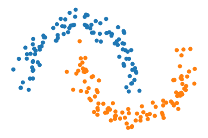

```python
import matplotlib.pyplot as plt
import numpy as np
from sklearn.datasets import make_moons

# Set random seeds
np.random.seed(42)
tf.random.set_seed(42)

X, y = make_moons(n_samples=200, noise=0.1)
y_hot = tf.keras.utils.to_categorical(
    y, num_classes=2)  # one-hot encoded labels

c = ["#1f77b4" if y_ == 0 else "#ff7f0e" for y_ in y]  # colours for each class
plt.axis("off")
plt.scatter(X[:, 0], X[:, 1], c=c)
plt.show()
```

### Defining Qnode

```python
import pennylane as qml

n_qubits = 2
dev = qml.device("default.qubit", wires=n_qubits)


@qml.qnode(dev)
def qnode(inputs, weights):
    qml.AngleEmbedding(inputs, wires=range(n_qubits))
    qml.BasicEntanglerLayers(weights, wires=range(n_qubits))
    return [qml.expval(qml.PauliZ(wires=i)) for i in range(n_qubits)]
```

```python
n_layers = 6
weight_shapes = {"weights": (n_layers, n_qubits)}
```

```python
type(weight_shapes)
```

```
dict
```

```python
qlayer = qml.qnn.KerasLayer(qnode, weight_shapes, output_dim=n_qubits)
```

```python
clayer_1 = tf.keras.layers.Dense(2)
clayer_2 = tf.keras.layers.Dense(2, activation="softmax")
model = tf.keras.models.Sequential([clayer_1, qlayer, clayer_2])
```

```python
opt = tf.keras.optimizers.SGD(learning_rate=0.2)
model.compile(opt, loss="mae", metrics=["accuracy"])

fitting = model.fit(X, y_hot, epochs=5, batch_size=5,
                    validation_split=0.25, verbose=2)
```

```
30/30 - 7s - loss: 0.4695 - accuracy: 0.6800 - val_loss: 0.3833 - val_accuracy: 0.7800 - 7s/epoch - 235ms/step
30/30 - 8s - loss: 0.3411 - accuracy: 0.7333 - val_loss: 0.2726 - val_accuracy: 0.7400 - 8s/epoch - 267ms/step
30/30 - 8s - loss: 0.2603 - accuracy: 0.7800 - val_loss: 0.2240 - val_accuracy: 0.8000 - 8s/epoch - 275ms/step
30/30 - 9s - loss: 0.2260 - accuracy: 0.7933 - val_loss: 0.2013 - val_accuracy: 0.8200 - 9s/epoch - 296ms/step
30/30 - 9s - loss: 0.1956 - accuracy: 0.8400 - val_loss: 0.1844 - val_accuracy: 0.8200 - 9s/epoch - 293ms/step
```

### Statevector result in Pennylane

```python
dev = qml.device('default.qubit', wires=2)


@qml.qnode(dev)
def example_circuit():
    qml.QubitStateVector(np.array([1, 0, 0, 0]), wires=range(2))
    return qml.state()
```

```python
cir_result = example_circuit()

print(type(cir_result))
print(cir_result)
```

```
<class 'pennylane.numpy.tensor.tensor'>
[1.+0.j 0.+0.j 0.+0.j 0.+0.j]
```

```python
cir_result[0]
```

```
tensor(1.+0.j, requires_grad=True)
```

```python
type(example_circuit())
```

```
pennylane.numpy.tensor.tensor
```

### Qnode Example

```python
n_qubits = 4
dev = qml.device("default.qubit", wires=n_qubits)


@qml.qnode(dev)
def qnode(inputs, weights_0, weight_1):
    qml.RX(inputs[0], wires=0)
    qml.RX(inputs[1], wires=1)

    qml.Rot(weights_0, wires=0)
    qml.RY(weight_1, wires=1)
    qml.Rot(weights_0, wires=0)
    qml.RY(weight_1, wires=1)
    qml.Rot(weights_0, wires=0)
    qml.RY(weight_1, wires=1)
    qml.CNOT(wires=[0, 1])
    return qml.expval(qml.PauliZ(0)), qml.expval(qml.PauliZ(1))
```

```python
weight_shapes = {"weights_0": 3, "weight_1": 1}
qlayer = qml.qnn.KerasLayer(qnode, weight_shapes, output_dim=2)
```

```python
clayer = tf.keras.layers.Dense(2)
model = tf.keras.models.Sequential([qlayer, clayer])
```

```python
model
```

```
<keras.engine.sequential.Sequential at 0x23c32a6e4c0>
```

```python
weight_shapes
```

```
{'weights_0': 3, 'weight_1': 1}
```

```python
model.summary
```

```
<bound method Model.summary of <keras.engine.sequential.Sequential object at 0x0000023C32A6E4C0>>
```

# QCNN - QNODE

## Creating devices - simulator with / without noise

- Number of qubits

```python
import pennylane as qml
from pennylane import numpy as np

n_qubits = 8
```

- Create devices with different readout error probabilities

```python
dev_noisy0 = qml.device("default.qubit", wires=n_qubits)
dev_noisy1 = qml.device("default.mixed", wires=n_qubits, readout_prob=0.0001)
dev_noisy2 = qml.device("default.mixed", wires=n_qubits, readout_prob=0.001)
dev_noisy3 = qml.device("default.mixed", wires=n_qubits, readout_prob=0.01)
dev_noisy4 = qml.device("default.mixed", wires=n_qubits, readout_prob=0.1)

dev_list = [dev_noisy0, dev_noisy1, dev_noisy2, dev_noisy3, dev_noisy4]
```

## Dataset - MNIST

```python
# MNIST datasets
dataset_name = 'mnist'
feature_reduction_method = 'resize256'


X_train, X_test, Y_train, Y_test = data_load_and_process(dataset=dataset_name,
                                                         classes=[0, 1],
                                                         feature_reduction=feature_reduction_method,
                                                         binary=True)
```

```python
print(X_train.shape)
print(X_test.shape)
```

```
(12665, 256)
(2115, 256)
```

```python
Y_train.count(-1)
```

```
6742
```

```python
print("# of 0s in train: ", Y_train.count(-1))
print("# of 1s in train: ", Y_train.count(1))

print("# of 0s in test: ", Y_test.count(-1))
print("# of 1s in test: ", Y_test.count(1))
```

```
# of 0s in train:  6742
# of 1s in train:  5923
# of 0s in test:  1135
# of 1s in test:  980
```

```python
from tensorflow.keras.utils import to_categorical


Y_train_label = (np.array(Y_train)+1)/2
Y_train_onehot = to_categorical(Y_train_label)

Y_test_label = (np.array(Y_test)+1)/2
Y_test_onehot = to_categorical(Y_test_label)
```

## QCNN circuits

### Circuit specifications

```python
# Circuit training hyper parameters of the optimizer: NesterovMomentumOptimizer
# steps = 200
# learning_rate = 0.01
# batch_size = 25

dataset_name = 'mnist'
Unitaries_list = ['U_TTN']
# Unitaries_list = ['U_TTN', 'U_9', 'U_15', 'U_13', 'U_14', 'U_SO4', 'U_5', 'U_6', 'U_SU4', 'U_SU4_no_pooling']
U_num_params_list = [2]
# U_num_params_list = [2, 2, 4, 6, 6, 6, 10, 10, 15, 15]
Encodings_list = ['resize256']
# Encodings_list = ['resize256', 'pca8', 'autoencoder8', 'pca16-1', 'autoencoder16-1', 'pca32-1', 'autoencoder32-1', 'pca30-1', 'autoencoder30-1']

circuit_type = 'QCNN'
# ['cross_entropy', 'mse', 'mse_lambda', 'classify_lambda', 'classify_lambda2']
cost_fn_type = 'mse'
lambda_value = 0.05
lambd_decs = False
num_obs_ploting = None
```

```python
def Encoding_to_Embedding(Encoding):
    # Amplitude Embedding / Angle Embedding
    if Encoding == 'resize256':
        Embedding = 'Amplitude'
    elif Encoding == 'pca8':
        Embedding = 'Angle'
    elif Encoding == 'autoencoder8':
        Embedding = 'Angle'

    # Amplitude Hybrid Embedding
    # 4 qubit block
    elif Encoding == 'pca32-1':
        Embedding = 'Amplitude-Hybrid4-1'
    elif Encoding == 'autoencoder32-1':
        Embedding = 'Amplitude-Hybrid4-1'

    elif Encoding == 'pca32-2':
        Embedding = 'Amplitude-Hybrid4-2'
    elif Encoding == 'autoencoder32-2':
        Embedding = 'Amplitude-Hybrid4-2'

    elif Encoding == 'pca32-3':
        Embedding = 'Amplitude-Hybrid4-3'
    elif Encoding == 'autoencoder32-3':
        Embedding = 'Amplitude-Hybrid4-3'

    elif Encoding == 'pca32-4':
        Embedding = 'Amplitude-Hybrid4-4'
    elif Encoding == 'autoencoder32-4':
        Embedding = 'Amplitude-Hybrid4-4'

    # 2 qubit block
    elif Encoding == 'pca16-1':
        Embedding = 'Amplitude-Hybrid2-1'
    elif Encoding == 'autoencoder16-1':
        Embedding = 'Amplitude-Hybrid2-1'

    elif Encoding == 'pca16-2':
        Embedding = 'Amplitude-Hybrid2-2'
    elif Encoding == 'autoencoder16-2':
        Embedding = 'Amplitude-Hybrid2-2'

    elif Encoding == 'pca16-3':
        Embedding = 'Amplitude-Hybrid2-3'
    elif Encoding == 'autoencoder16-3':
        Embedding = 'Amplitude-Hybrid2-3'

    elif Encoding == 'pca16-4':
        Embedding = 'Amplitude-Hybrid2-4'
    elif Encoding == 'autoencoder16-4':
        Embedding = 'Amplitude-Hybrid2-4'

    # Angular HybridEmbedding
    # 4 qubit block
    elif Encoding == 'pca30-1':
        Embedding = 'Angular-Hybrid4-1'
    elif Encoding == 'autoencoder30-1':
        Embedding = 'Angular-Hybrid4-1'

    elif Encoding == 'pca30-2':
        Embedding = 'Angular-Hybrid4-2'
    elif Encoding == 'autoencoder30-2':
        Embedding = 'Angular-Hybrid4-2'

    elif Encoding == 'pca30-3':
        Embedding = 'Angular-Hybrid4-3'
    elif Encoding == 'autoencoder30-3':
        Embedding = 'Angular-Hybrid4-3'

    elif Encoding == 'pca30-4':
        Embedding = 'Angular-Hybrid4-4'
    elif Encoding == 'autoencoder30-4':
        Embedding = 'Angular-Hybrid4-4'

    # 2 qubit block
    elif Encoding == 'pca12-1':
        Embedding = 'Angular-Hybrid2-1'
    elif Encoding == 'autoencoder12-1':
        Embedding = 'Angular-Hybrid2-1'

    elif Encoding == 'pca12-2':
        Embedding = 'Angular-Hybrid2-2'
    elif Encoding == 'autoencoder12-2':
        Embedding = 'Angular-Hybrid2-2'

    elif Encoding == 'pca12-3':
        Embedding = 'Angular-Hybrid2-3'
    elif Encoding == 'autoencoder12-3':
        Embedding = 'Angular-Hybrid2-3'

    elif Encoding == 'pca12-4':
        Embedding = 'Angular-Hybrid2-4'
    elif Encoding == 'autoencoder12-4':
        Embedding = 'Angular-Hybrid2-4'

    # Two Gates Compact Encoding
    elif Encoding == 'pca16-compact':
        Embedding = 'Angle-compact'
    elif Encoding == 'autoencoder16-compact':
        Embedding = 'Angle-compact'
    return Embedding
```

```python
Embedding = Encoding_to_Embedding(Encodings_list[0])
Embedding
```

```
'Amplitude'
```

```python
# Run modules
%run QCNN_modules2/Angular_hybrid.py
%run QCNN_modules2/embedding.py
%run QCNN_modules2/unitary.py

# %run QCNN_modules2/QCNN_circuit.py
```

```python
# QCNN circuit build with data encoding, convolutional layers, pooling layers, and measurement
def QCNN_circuit_node(inputs, params):

    # Data Embedding
    data_embedding(inputs, embedding_type=Embedding)

    # Quantum Convolutional Neural Network
    # Convolutional Layer #1
    if U == "U_TTN":
        # Layer 1 - Convolution
        qml.RY(params[0], wires=7)
        qml.RY(params[1], wires=0)
        qml.CNOT(wires=[7, 0])
        for i in range(0, 8, 2):
            qml.RY(params[0], wires=i)
            qml.RY(params[1], wires=i+1)
            qml.CNOT(wires=[i, i+1])
        for i in range(1, 7, 2):
            qml.RY(params[0], wires=i)
            qml.RY(params[1], wires=i+1)
            qml.CNOT(wires=[i, i+1])

        # Layer 1 - Pooling
        for i in range(0, 8, 2):
            qml.CRZ(params[6], wires=[i+1, i])
            qml.PauliX(wires=i+1)
            qml.CRX(params[7], wires=[i+1, i])

        # Layer 2 - Convolution
        qml.RY(params[2], wires=6)
        qml.RY(params[3], wires=0)
        qml.CNOT(wires=[6, 0])
        qml.RY(params[2], wires=0)
        qml.RY(params[3], wires=2)
        qml.CNOT(wires=[0, 2])
        qml.RY(params[2], wires=4)
        qml.RY(params[3], wires=6)
        qml.CNOT(wires=[4, 6])
        qml.RY(params[2], wires=2)
        qml.RY(params[3], wires=4)
        qml.CNOT(wires=[2, 4])

        # Layer 2 - Pooling
        qml.CRZ(params[8], wires=[2, 0])
        qml.PauliX(wires=2)
        qml.CRX(params[9], wires=[2, 0])
        qml.CRZ(params[8], wires=[6, 4])
        qml.PauliX(wires=6)
        qml.CRX(params[9], wires=[6, 4])

        # Layer 3 - Convolution
        qml.RY(params[4], wires=4)
        qml.RY(params[5], wires=0)
        qml.CNOT(wires=[4, 0])

        # Layer 3 - Pooling
        qml.CRZ(params[10], wires=[4, 0])
        qml.PauliX(wires=4)
        qml.CRX(params[11], wires=[4, 0])

    # Convolutional Layer #2
    elif U == "U_9":
        # Layer 1 - Convolution
        qml.Hadamard(wires=7)
        qml.Hadamard(wires=0)
        qml.CZ(wires=[7, 0])
        qml.RX(params[0], wires=7)
        qml.RX(params[1], wires=0)
        for i in range(0, 8, 2):
            qml.Hadamard(wires=i)
            qml.Hadamard(wires=i+1)
            qml.CZ(wires=[i, i+1])
            qml.RX(params[0], wires=i)
            qml.RX(params[1], wires=i+1)
        for i in range(1, 7, 2):
            qml.Hadamard(wires=i)
            qml.Hadamard(wires=i+1)
            qml.CZ(wires=[i, i+1])
            qml.RX(params[0], wires=i)
            qml.RX(params[1], wires=i+1)

        # Layer 1 - Pooling
        for i in range(0, 8, 2):
            qml.CRZ(params[6], wires=[i+1, i])
            qml.PauliX(wires=i+1)
            qml.CRX(params[7], wires=[i+1, i])

        # Layer 2 - Convolution
        qml.Hadamard(wires=6)
        qml.Hadamard(wires=0)
        qml.CZ(wires=[6, 0])
        qml.RX(params[2], wires=6)
        qml.RX(params[3], wires=0)
        qml.Hadamard(wires=0)
        qml.Hadamard(wires=2)
        qml.CZ(wires=[0, 2])
        qml.RX(params[2], wires=0)
        qml.RX(params[3], wires=2)
        qml.Hadamard(wires=4)
        qml.Hadamard(wires=6)
        qml.CZ(wires=[4, 6])
        qml.RX(params[2], wires=4)
        qml.RX(params[3], wires=6)
        qml.Hadamard(wires=2)
        qml.Hadamard(wires=4)
        qml.CZ(wires=[2, 4])
        qml.RX(params[2], wires=2)
        qml.RX(params[3], wires=4)

        # Layer 2 - Pooling
        qml.CRZ(params[8], wires=[2, 0])
        qml.PauliX(wires=2)
        qml.CRX(params[9], wires=[2, 0])
        qml.CRZ(params[8], wires=[6, 4])
        qml.PauliX(wires=6)
        qml.CRX(params[9], wires=[6, 4])

        # Layer 3 - Convolution
        qml.Hadamard(wires=4)
        qml.Hadamard(wires=0)
        qml.CZ(wires=[4, 0])
        qml.RX(params[4], wires=4)
        qml.RX(params[5], wires=0)

        # Layer 3 - Pooling
        qml.CRZ(params[10], wires=[4, 0])
        qml.PauliX(wires=4)
        qml.CRX(params[11], wires=[4, 0])

    # Convolutional Layer #3
    elif U == "U_15":
        # Layer 1 - Convolution
        qml.RY(params[0], wires=7)
        qml.RY(params[1], wires=0)
        qml.CNOT(wires=[0, 7])
        qml.RY(params[2], wires=7)
        qml.RY(params[3], wires=0)
        qml.CNOT(wires=[7, 0])
        for i in range(0, 8, 2):
            qml.RY(params[0], wires=i)
            qml.RY(params[1], wires=i+1)
            qml.CNOT(wires=[i+1, i])
            qml.RY(params[2], wires=i)
            qml.RY(params[3], wires=i+1)
            qml.CNOT(wires=[i, i+1])
        for i in range(1, 7, 2):
            qml.RY(params[0], wires=i)
            qml.RY(params[1], wires=i+1)
            qml.CNOT(wires=[i+1, i])
            qml.RY(params[2], wires=i)
            qml.RY(params[3], wires=i+1)
            qml.CNOT(wires=[i, i+1])

        # Layer 1 - Pooling
        for i in range(0, 8, 2):
            qml.CRZ(params[12], wires=[i+1, i])
            qml.PauliX(wires=i+1)
            qml.CRX(params[13], wires=[i+1, i])

        # Layer 2 - Convolution
        qml.RY(params[4], wires=6)
        qml.RY(params[5], wires=0)
        qml.CNOT(wires=[6, 0])
        qml.RY(params[6], wires=6)
        qml.RY(params[7], wires=0)
        qml.CNOT(wires=[6, 0])
        qml.RY(params[4], wires=0)
        qml.RY(params[5], wires=2)
        qml.CNOT(wires=[0, 2])
        qml.RY(params[6], wires=0)
        qml.RY(params[7], wires=2)
        qml.CNOT(wires=[0, 2])
        qml.RY(params[4], wires=4)
        qml.RY(params[5], wires=6)
        qml.CNOT(wires=[4, 6])
        qml.RY(params[6], wires=4)
        qml.RY(params[7], wires=6)
        qml.CNOT(wires=[4, 6])
        qml.RY(params[4], wires=2)
        qml.RY(params[5], wires=4)
        qml.CNOT(wires=[2, 4])
        qml.RY(params[6], wires=2)
        qml.RY(params[7], wires=4)
        qml.CNOT(wires=[2, 4])

        # Layer 2 - Pooling
        qml.CRZ(params[14], wires=[2, 0])
        qml.PauliX(wires=2)
        qml.CRX(params[15], wires=[2, 0])
        qml.CRZ(params[14], wires=[6, 4])
        qml.PauliX(wires=6)
        qml.CRX(params[15], wires=[6, 4])
```

```python
        # Layer 3 - Convolution
        qml.RY(params[8], wires=4)
        qml.RY(params[9], wires=0)
        qml.CNOT(wires=[4, 0])
        qml.RY(params[10], wires=4)
        qml.RY(params[11], wires=0)
        qml.CNOT(wires=[4, 0])

        # Layer 3 - Pooling
        qml.CRZ(params[16], wires=[4, 0])
        qml.PauliX(wires=4)
        qml.CRX(params[17], wires=[4, 0])

    # Convolutional Layer #4
    elif U == "U_13":
        # Layer 1 - Convolution
        qml.RY(params[0], wires=7)
        qml.RY(params[1], wires=0)
        qml.CRZ(params[2], wires=[0, 7])
        qml.RY(params[3], wires=7)
        qml.RY(params[4], wires=0)
        qml.CRZ(params[5], wires=[7, 0])
        for i in range(0, 8, 2):
            qml.RY(params[0], wires=i)
            qml.RY(params[1], wires=i+1)
            qml.CRZ(params[2], wires=[i+1, i])
            qml.RY(params[3], wires=i)
            qml.RY(params[4], wires=i+1)
            qml.CRZ(params[5], wires=[i, i+1])
        for i in range(1, 7, 2):
            qml.RY(params[0], wires=i)
            qml.RY(params[1], wires=i+1)
            qml.CRZ(params[2], wires=[i+1, i])
            qml.RY(params[3], wires=i)
            qml.RY(params[4], wires=i+1)
            qml.CRZ(params[5], wires=[i, i+1])

        # Layer 1 - Pooling
        for i in range(0, 8, 2):
            qml.CRZ(params[18], wires=[i+1, i])
            qml.PauliX(wires=i+1)
            qml.CRX(params[19], wires=[i+1, i])

        # Layer 2 - Convolution
        qml.RY(params[6], wires=6)
        qml.RY(params[7], wires=0)
        qml.CRZ(params[8], wires=[6, 0])
        qml.RY(params[9], wires=6)
        qml.RY(params[10], wires=0)
        qml.CRZ(params[11], wires=[6, 0])
        qml.RY(params[6], wires=0)
        qml.RY(params[7], wires=2)
        qml.CRZ(params[8], wires=[0, 2])
        qml.RY(params[9], wires=0)
        qml.RY(params[10], wires=2)
        qml.CRZ(params[11], wires=[0, 2])
        qml.RY(params[6], wires=4)
        qml.RY(params[7], wires=6)
        qml.CRZ(params[8], wires=[4, 6])
        qml.RY(params[9], wires=4)
        qml.RY(params[10], wires=6)
        qml.CRZ(params[11], wires=[4, 6])
        qml.RY(params[6], wires=2)
        qml.RY(params[7], wires=4)
        qml.CRZ(params[8], wires=[2, 4])
        qml.RY(params[9], wires=2)
        qml.RY(params[10], wires=4)
        qml.CRZ(params[11], wires=[2, 4])

        # Layer 2 - Pooling
        qml.CRZ(params[20], wires=[2, 0])
        qml.PauliX(wires=2)
        qml.CRX(params[21], wires=[2, 0])
        qml.CRZ(params[20], wires=[6, 4])
        qml.PauliX(wires=6)
        qml.CRX(params[21], wires=[6, 4])

        # Layer 3 - Convolution
        qml.RY(params[12], wires=4)
        qml.RY(params[13], wires=0)
        qml.CRZ(params[14], wires=[4, 0])
        qml.RY(params[15], wires=4)
        qml.RY(params[16], wires=0)
        qml.CRZ(params[17], wires=[4, 0])

        # Layer 3 - Pooling
        qml.CRZ(params[22], wires=[4, 0])
        qml.PauliX(wires=4)
        qml.CRX(params[23], wires=[4, 0])

    # Convolutional Layer #5
    elif U == "U_14":
        # Layer 1 - Convolution
        qml.RY(params[0], wires=7)
        qml.RY(params[1], wires=0)
        qml.CRX(params[2], wires=[0, 7])
        qml.RY(params[3], wires=7)
        qml.RY(params[4], wires=0)
        qml.CRX(params[5], wires=[7, 0])
        for i in range(0, 8, 2):
            qml.RY(params[0], wires=i)
            qml.RY(params[1], wires=i+1)
            qml.CRX(params[2], wires=[i+1, i])
            qml.RY(params[3], wires=i)
            qml.RY(params[4], wires=i+1)
            qml.CRX(params[5], wires=[i, i+1])
        for i in range(1, 7, 2):
            qml.RY(params[0], wires=i)
            qml.RY(params[1], wires=i+1)
            qml.CRX(params[2], wires=[i+1, i])
            qml.RY(params[3], wires=i)
            qml.RY(params[4], wires=i+1)
            qml.CRX(params[5], wires=[i, i+1])

        # Layer 1 - Pooling
        for i in range(0, 8, 2):
            qml.CRZ(params[18], wires=[i+1, i])
            qml.PauliX(wires=i+1)
            qml.CRX(params[19], wires=[i+1, i])

        # Layer 2 - Convolution
        qml.RY(params[6], wires=6)
        qml.RY(params[7], wires=0)
        qml.CRX(params[8], wires=[0, 6])
        qml.RY(params[9], wires=6)
        qml.RY(params[10], wires=0)
        qml.CRX(params[11], wires=[6, 0])
        qml.RY(params[6], wires=0)
        qml.RY(params[7], wires=2)
        qml.CRX(params[8], wires=[2, 0])
        qml.RY(params[9], wires=0)
        qml.RY(params[10], wires=2)
        qml.CRX(params[11], wires=[0, 2])
        qml.RY(params[6], wires=4)
        qml.RY(params[7], wires=6)
        qml.CRX(params[8], wires=[6, 4])
        qml.RY(params[9], wires=4)
        qml.RY(params[10], wires=6)
        qml.CRX(params[11], wires=[4, 6])
        qml.RY(params[6], wires=2)
        qml.RY(params[7], wires=4)
        qml.CRX(params[8], wires=[4, 2])
        qml.RY(params[9], wires=2)
        qml.RY(params[10], wires=4)
        qml.CRX(params[11], wires=[2, 4])

        # Layer 2 - Pooling
        qml.CRZ(params[20], wires=[2, 0])
        qml.PauliX(wires=2)
        qml.CRX(params[21], wires=[2, 0])
        qml.CRZ(params[20], wires=[6, 4])
        qml.PauliX(wires=6)
        qml.CRX(params[21], wires=[6, 4])

        # Layer 3 - Convolution
        qml.RY(params[12], wires=4)
        qml.RY(params[13], wires=0)
        qml.CRX(params[14], wires=[0, 4])
        qml.RY(params[15], wires=4)
        qml.RY(params[16], wires=0)
        qml.CRX(params[17], wires=[4, 0])

        # Layer 3 - Pooling
        qml.CRZ(params[22], wires=[4, 0])
        qml.PauliX(wires=4)
        qml.CRX(params[23], wires=[4, 0])

    # Convolutional Layer #6
    elif U == "U_SO4":
        # Layer 1 - Convolution
        qml.RY(params[0], wires=7)
        qml.RY(params[1], wires=0)
        qml.CNOT(wires=[7, 0])
        qml.RY(params[2], wires=7)
        qml.RY(params[3], wires=0)
        qml.CNOT(wires=[7, 0])
        qml.RY(params[4], wires=7)
        qml.RY(params[5], wires=0)
        for i in range(0, 8, 2):
            qml.RY(params[0], wires=i)
            qml.RY(params[1], wires=i+1)
            qml.CNOT(wires=[i, i+1])
            qml.RY(params[2], wires=i)
            qml.RY(params[3], wires=i+1)
            qml.CNOT(wires=[i, i+1])
            qml.RY(params[4], wires=i)
            qml.RY(params[5], wires=i+1)
        for i in range(1, 7, 2):
            qml.RY(params[0], wires=i)
            qml.RY(params[1], wires=i+1)
            qml.CNOT(wires=[i, i+1])
            qml.RY(params[2], wires=i)
            qml.RY(params[3], wires=i+1)
            qml.CNOT(wires=[i, i+1])
            qml.RY(params[4], wires=i)
            qml.RY(params[5], wires=i+1)
```

```python
        # Layer 1 - Pooling
        for i in range(0, 8, 2):
            qml.CRZ(params[18], wires=[i+1, i])
            qml.PauliX(wires=i+1)
            qml.CRX(params[19], wires=[i+1, i])

        # Layer 2 - Convolution
        qml.RY(params[6], wires=6)
        qml.RY(params[7], wires=0)
        qml.CNOT(wires=[6, 0])
        qml.RY(params[8], wires=6)
        qml.RY(params[9], wires=0)
        qml.CNOT(wires=[6, 0])
        qml.RY(params[10], wires=6)
        qml.RY(params[11], wires=0)
        qml.RY(params[6], wires=0)
        qml.RY(params[7], wires=2)
        qml.CNOT(wires=[0, 2])
        qml.RY(params[8], wires=0)
        qml.RY(params[9], wires=2)
        qml.CNOT(wires=[0, 2])
        qml.RY(params[10], wires=0)
        qml.RY(params[11], wires=2)
        qml.RY(params[6], wires=4)
        qml.RY(params[7], wires=6)
        qml.CNOT(wires=[4, 6])
        qml.RY(params[8], wires=4)
        qml.RY(params[9], wires=6)
        qml.CNOT(wires=[4, 6])
        qml.RY(params[10], wires=4)
        qml.RY(params[11], wires=6)
        qml.RY(params[6], wires=2)
        qml.RY(params[7], wires=4)
        qml.CNOT(wires=[2, 4])
        qml.RY(params[8], wires=2)
        qml.RY(params[9], wires=4)
        qml.CNOT(wires=[2, 4])
        qml.RY(params[10], wires=2)
        qml.RY(params[11], wires=4)

        # Layer 2 - Pooling
        qml.CRZ(params[20], wires=[2, 0])
        qml.PauliX(wires=2)
        qml.CRX(params[21], wires=[2, 0])
        qml.CRZ(params[20], wires=[6, 4])
        qml.PauliX(wires=6)
        qml.CRX(params[21], wires=[6, 4])

        # Layer 3 - Convolution
        qml.RY(params[12], wires=4)
        qml.RY(params[13], wires=0)
        qml.CNOT(wires=[4, 0])
        qml.RY(params[14], wires=4)
        qml.RY(params[15], wires=0)
        qml.CNOT(wires=[4, 0])
        qml.RY(params[16], wires=4)
        qml.RY(params[17], wires=0)

        # Layer 3 - Pooling
        qml.CRZ(params[22], wires=[4, 0])
        qml.PauliX(wires=4)
        qml.CRX(params[23], wires=[4, 0])

    # Convolutional Layer #7
    elif U == "U_5":
        # Layer 1 - Convolution
        qml.RX(params[0], wires=7)
        qml.RX(params[1], wires=0)
        qml.RZ(params[2], wires=7)
        qml.RZ(params[3], wires=0)
        qml.CRZ(params[4], wires=[0, 7])
        qml.CRZ(params[5], wires=[7, 0])
        qml.RX(params[6], wires=7)
        qml.RX(params[7], wires=0)
        qml.RZ(params[8], wires=7)
        qml.RZ(params[9], wires=0)
        for i in range(0, 8, 2):
            qml.RX(params[0], wires=i)
            qml.RX(params[1], wires=i+1)
            qml.RZ(params[2], wires=i)
            qml.RZ(params[3], wires=i+1)
            qml.CRZ(params[4], wires=[i+1, i])
            qml.CRZ(params[5], wires=[i, i+1])
            qml.RX(params[6], wires=i)
            qml.RX(params[7], wires=i+1)
            qml.RZ(params[8], wires=i)
            qml.RZ(params[9], wires=i+1)
        for i in range(1, 7, 2):
            qml.RX(params[0], wires=i)
            qml.RX(params[1], wires=i+1)
            qml.RZ(params[2], wires=i)
            qml.RZ(params[3], wires=i+1)
            qml.CRZ(params[4], wires=[i+1, i])
            qml.CRZ(params[5], wires=[i, i+1])
            qml.RX(params[6], wires=i)
            qml.RX(params[7], wires=i+1)
            qml.RZ(params[8], wires=i)
            qml.RZ(params[9], wires=i+1)

        # Layer 1 - Pooling
        for i in range(0, 8, 2):
            qml.CRZ(params[30], wires=[i+1, i])
            qml.PauliX(wires=i+1)
            qml.CRX(params[31], wires=[i+1, i])

        # Layer 2 - Convolution
        qml.RX(params[10], wires=6)
        qml.RX(params[11], wires=0)
        qml.RZ(params[12], wires=6)
        qml.RZ(params[13], wires=0)
        qml.CRZ(params[14], wires=[0, 6])
        qml.CRZ(params[15], wires=[6, 0])
        qml.RX(params[16], wires=6)
        qml.RX(params[17], wires=0)
        qml.RZ(params[18], wires=6)
        qml.RZ(params[19], wires=0)
        qml.RX(params[10], wires=0)
        qml.RX(params[11], wires=2)
        qml.RZ(params[12], wires=0)
        qml.RZ(params[13], wires=2)
        qml.CRZ(params[14], wires=[2, 0])
        qml.CRZ(params[15], wires=[0, 2])
        qml.RX(params[16], wires=0)
        qml.RX(params[17], wires=2)
        qml.RZ(params[18], wires=0)
        qml.RZ(params[19], wires=2)
        qml.RX(params[10], wires=4)
        qml.RX(params[11], wires=6)
        qml.RZ(params[12], wires=4)
        qml.RZ(params[13], wires=6)
        qml.CRZ(params[14], wires=[6, 4])
        qml.CRZ(params[15], wires=[4, 6])
        qml.RX(params[16], wires=4)
        qml.RX(params[17], wires=6)
        qml.RZ(params[18], wires=4)
        qml.RZ(params[19], wires=6)
        qml.RX(params[10], wires=2)
        qml.RX(params[11], wires=4)
        qml.RZ(params[12], wires=2)
        qml.RZ(params[13], wires=4)
        qml.CRZ(params[14], wires=[4, 2])
        qml.CRZ(params[15], wires=[2, 4])
        qml.RX(params[16], wires=2)
        qml.RX(params[17], wires=4)
        qml.RZ(params[18], wires=2)
        qml.RZ(params[19], wires=4)

        # Layer 2 - Pooling
        qml.CRZ(params[32], wires=[2, 0])
        qml.PauliX(wires=2)
        qml.CRX(params[33], wires=[2, 0])
        qml.CRZ(params[32], wires=[6, 4])
        qml.PauliX(wires=6)
        qml.CRX(params[33], wires=[6, 4])

        # Layer 3 - Convolution
        qml.RX(params[20], wires=4)
        qml.RX(params[21], wires=0)
        qml.RZ(params[22], wires=4)
        qml.RZ(params[23], wires=0)
        qml.CRZ(params[24], wires=[0, 4])
        qml.CRZ(params[25], wires=[4, 0])
        qml.RX(params[26], wires=4)
        qml.RX(params[27], wires=0)
        qml.RZ(params[28], wires=4)
        qml.RZ(params[29], wires=0)

        # Layer 3 - Pooling
        qml.CRZ(params[34], wires=[4, 0])
        qml.PauliX(wires=4)
        qml.CRX(params[35], wires=[4, 0])

    # Convolutional Layer #8
    elif U == "U_6":
        # Layer 1 - Convolution
        qml.RX(params[0], wires=7)
        qml.RX(params[1], wires=0)
        qml.RZ(params[2], wires=7)
        qml.RZ(params[3], wires=0)
        qml.CRX(params[4], wires=[0, 7])
        qml.CRX(params[5], wires=[7, 0])
        qml.RX(params[6], wires=7)
        qml.RX(params[7], wires=0)
        qml.RZ(params[8], wires=7)
        qml.RZ(params[9], wires=0)
        for i in range(0, 8, 2):
            qml.RX(params[0], wires=i)
            qml.RX(params[1], wires=i+1)
            qml.RZ(params[2], wires=i)
            qml.RZ(params[3], wires=i+1)
            qml.CRX(params[4], wires=[i+1, i])
            qml.CRX(params[5], wires=[i, i+1])
            qml.RX(params[6], wires=i)
            qml.RX(params[7], wires=i+1)
            qml.RZ(params[8], wires=i)
            qml.RZ(params[9], wires=i+1)
        for i in range(1, 7, 2):
            qml.RX(params[0], wires=i)
            qml.RX(params[1], wires=i+1)
            qml.RZ(params[2], wires=i)
            qml.RZ(params[3], wires=i+1)
            qml.CRX(params[4], wires=[i+1, i])
            qml.CRX(params[5], wires=[i, i+1])
            qml.RX(params[6], wires=i)
            qml.RX(params[7], wires=i+1)
            qml.RZ(params[8], wires=i)
            qml.RZ(params[9], wires=i+1)
```

```python
        # Layer 1 - Pooling
        for i in range(0, 8, 2):
            qml.CRZ(params[30], wires=[i+1, i])
            qml.PauliX(wires=i+1)
            qml.CRX(params[31], wires=[i+1, i])

        # Layer 2 - Convolution
        qml.RX(params[10], wires=6)
        qml.RX(params[11], wires=0)
        qml.RZ(params[12], wires=6)
        qml.RZ(params[13], wires=0)
        qml.CRX(params[14], wires=[0, 6])
        qml.CRX(params[15], wires=[6, 0])
        qml.RX(params[16], wires=6)
        qml.RX(params[17], wires=0)
        qml.RZ(params[18], wires=6)
        qml.RZ(params[19], wires=0)
        qml.RX(params[10], wires=0)
        qml.RX(params[11], wires=2)
        qml.RZ(params[12], wires=0)
        qml.RZ(params[13], wires=2)
        qml.CRX(params[14], wires=[2, 0])
        qml.CRX(params[15], wires=[0, 2])
        qml.RX(params[16], wires=0)
        qml.RX(params[17], wires=2)
        qml.RZ(params[18], wires=0)
        qml.RZ(params[19], wires=2)
        qml.RX(params[10], wires=4)
        qml.RX(params[11], wires=6)
        qml.RZ(params[12], wires=4)
        qml.RZ(params[13], wires=6)
        qml.CRX(params[14], wires=[6, 4])
        qml.CRX(params[15], wires=[4, 6])
        qml.RX(params[16], wires=4)
        qml.RX(params[17], wires=6)
        qml.RZ(params[18], wires=4)
        qml.RZ(params[19], wires=6)
        qml.RX(params[10], wires=2)
        qml.RX(params[11], wires=4)
        qml.RZ(params[12], wires=2)
        qml.RZ(params[13], wires=4)
        qml.CRX(params[14], wires=[4, 2])
        qml.CRX(params[15], wires=[2, 4])
        qml.RX(params[16], wires=2)
        qml.RX(params[17], wires=4)
        qml.RZ(params[18], wires=2)
        qml.RZ(params[19], wires=4)

        # Layer 2 - Pooling
        qml.CRZ(params[32], wires=[2, 0])
        qml.PauliX(wires=2)
        qml.CRX(params[33], wires=[2, 0])
        qml.CRZ(params[32], wires=[6, 4])
        qml.PauliX(wires=6)
        qml.CRX(params[33], wires=[6, 4])

        # Layer 3 - Convolution
        qml.RX(params[20], wires=4)
        qml.RX(params[21], wires=0)
        qml.RZ(params[22], wires=4)
        qml.RZ(params[23], wires=0)
        qml.CRX(params[24], wires=[0, 4])
        qml.CRX(params[25], wires=[4, 0])
        qml.RX(params[26], wires=4)
        qml.RX(params[27], wires=0)
        qml.RZ(params[28], wires=4)
        qml.RZ(params[29], wires=0)

        # Layer 3 - Pooling
        qml.CRZ(params[34], wires=[4, 0])
        qml.PauliX(wires=4)
        qml.CRX(params[35], wires=[4, 0])

    # Convolutional Layer #9a
    elif U == "U_SU4":
        # Layer 1 - Convolution
        qml.U3(params[0], params[1], params[2], wires=7)
        qml.U3(params[3], params[4], params[5], wires=0)
        qml.CNOT(wires=[7, 0])
        qml.RY(params[6], wires=7)
        qml.RZ(params[7], wires=0)
        qml.CNOT(wires=[0, 7])
        qml.RY(params[8], wires=7)
        qml.CNOT(wires=[7, 0])
        qml.U3(params[9], params[10], params[11], wires=7)
        qml.U3(params[12], params[13], params[14], wires=0)
        for i in range(0, 8, 2):
            qml.U3(params[0], params[1], params[2], wires=i)
            qml.U3(params[3], params[4], params[5], wires=i+1)
            qml.CNOT(wires=[i, i+1])
            qml.RY(params[6], wires=i)
            qml.RZ(params[7], wires=i+1)
            qml.CNOT(wires=[i+1, i])
            qml.RY(params[8], wires=i)
            qml.CNOT(wires=[i, i+1])
            qml.U3(params[9], params[10], params[11], wires=i)
            qml.U3(params[12], params[13], params[14], wires=i+1)
        for i in range(1, 7, 2):
            qml.U3(params[0], params[1], params[2], wires=i)
            qml.U3(params[3], params[4], params[5], wires=i+1)
            qml.CNOT(wires=[i, i+1])
            qml.RY(params[6], wires=i)
            qml.RZ(params[7], wires=i+1)
            qml.CNOT(wires=[i+1, i])
            qml.RY(params[8], wires=i)
            qml.CNOT(wires=[i, i+1])
            qml.U3(params[9], params[10], params[11], wires=i)
            qml.U3(params[12], params[13], params[14], wires=i+1)

        # Layer 1 - Pooling
        for i in range(0, 8, 2):
            qml.CRZ(params[45], wires=[i+1, i])
            qml.PauliX(wires=i+1)
            qml.CRX(params[46], wires=[i+1, i])

        # Layer 2 - Convolution
        qml.U3(params[15], params[16], params[17], wires=6)
        qml.U3(params[18], params[19], params[20], wires=0)
        qml.CNOT(wires=[6, 0])
        qml.RY(params[21], wires=6)
        qml.RZ(params[22], wires=0)
        qml.CNOT(wires=[0, 6])
        qml.RY(params[23], wires=6)
        qml.CNOT(wires=[6, 0])
        qml.U3(params[24], params[25], params[26], wires=6)
        qml.U3(params[27], params[28], params[29], wires=0)
        qml.U3(params[15], params[16], params[17], wires=0)
        qml.U3(params[18], params[19], params[20], wires=2)
        qml.CNOT(wires=[0, 2])
        qml.RY(params[21], wires=0)
        qml.RZ(params[22], wires=2)
        qml.CNOT(wires=[2, 0])
        qml.RY(params[23], wires=0)
        qml.CNOT(wires=[0, 2])
        qml.U3(params[24], params[25], params[26], wires=0)
        qml.U3(params[27], params[28], params[29], wires=2)
        qml.U3(params[15], params[16], params[17], wires=4)
        qml.U3(params[18], params[19], params[20], wires=6)
        qml.CNOT(wires=[4, 6])
        qml.RY(params[21], wires=4)
        qml.RZ(params[22], wires=6)
        qml.CNOT(wires=[6, 4])
        qml.RY(params[23], wires=4)
        qml.CNOT(wires=[4, 6])
        qml.U3(params[24], params[25], params[26], wires=4)
        qml.U3(params[27], params[28], params[29], wires=6)
        qml.U3(params[15], params[16], params[17], wires=2)
        qml.U3(params[18], params[19], params[20], wires=4)
        qml.CNOT(wires=[2, 4])
        qml.RY(params[21], wires=2)
        qml.RZ(params[22], wires=4)
        qml.CNOT(wires=[4, 2])
        qml.RY(params[23], wires=2)
        qml.CNOT(wires=[2, 4])
        qml.U3(params[24], params[25], params[26], wires=2)
        qml.U3(params[27], params[28], params[29], wires=4)
```

```python
        # Layer 2 - Pooling
        qml.CRZ(params[47], wires=[2, 0])
        qml.PauliX(wires=2)
        qml.CRX(params[48], wires=[2, 0])
        qml.CRZ(params[47], wires=[6, 4])
        qml.PauliX(wires=6)
        qml.CRX(params[48], wires=[6, 4])

        # Layer 3 - Convolution
        qml.U3(params[30], params[31], params[32], wires=4)
        qml.U3(params[33], params[34], params[35], wires=0)
        qml.CNOT(wires=[4, 0])
        qml.RY(params[36], wires=4)
        qml.RZ(params[37], wires=0)
        qml.CNOT(wires=[0, 4])
        qml.RY(params[38], wires=4)
        qml.CNOT(wires=[4, 0])
        qml.U3(params[39], params[40], params[41], wires=4)
        qml.U3(params[42], params[43], params[44], wires=0)

        # Layer 3 - Pooling
        qml.CRZ(params[49], wires=[4, 0])
        qml.PauliX(wires=4)
        qml.CRX(params[50], wires=[4, 0])

    # Convolutional Layer #9b
    elif U == "U_SU4_no_pooling":
        # Layer 1 - Convolution
        qml.U3(params[0], params[1], params[2], wires=7)
        qml.U3(params[3], params[4], params[5], wires=0)
        qml.CNOT(wires=[7, 0])
        qml.RY(params[6], wires=7)
        qml.RZ(params[7], wires=0)
        qml.CNOT(wires=[0, 7])
        qml.RY(params[8], wires=7)
        qml.CNOT(wires=[7, 0])
        qml.U3(params[9], params[10], params[11], wires=7)
        qml.U3(params[12], params[13], params[14], wires=0)
        for i in range(0, 8, 2):
            qml.U3(params[0], params[1], params[2], wires=i)
            qml.U3(params[3], params[4], params[5], wires=i+1)
            qml.CNOT(wires=[i, i+1])
            qml.RY(params[6], wires=i)
            qml.RZ(params[7], wires=i+1)
            qml.CNOT(wires=[i+1, i])
            qml.RY(params[8], wires=i)
            qml.CNOT(wires=[i, i+1])
            qml.U3(params[9], params[10], params[11], wires=i)
            qml.U3(params[12], params[13], params[14], wires=i+1)
        for i in range(1, 7, 2):
            qml.U3(params[0], params[1], params[2], wires=i)
            qml.U3(params[3], params[4], params[5], wires=i+1)
            qml.CNOT(wires=[i, i+1])
            qml.RY(params[6], wires=i)
            qml.RZ(params[7], wires=i+1)
            qml.CNOT(wires=[i+1, i])
            qml.RY(params[8], wires=i)
            qml.CNOT(wires=[i, i+1])
            qml.U3(params[9], params[10], params[11], wires=i)
            qml.U3(params[12], params[13], params[14], wires=i+1)

        # Layer 2 - Convolution
        qml.U3(params[15], params[16], params[17], wires=6)
        qml.U3(params[18], params[19], params[20], wires=0)
        qml.CNOT(wires=[6, 0])
        qml.RY(params[21], wires=6)
        qml.RZ(params[22], wires=0)
        qml.CNOT(wires=[0, 6])
        qml.RY(params[23], wires=6)
        qml.CNOT(wires=[6, 0])
        qml.U3(params[24], params[25], params[26], wires=6)
        qml.U3(params[27], params[28], params[29], wires=0)
        qml.U3(params[15], params[16], params[17], wires=0)
        qml.U3(params[18], params[19], params[20], wires=2)
        qml.CNOT(wires=[0, 2])
        qml.RY(params[21], wires=0)
        qml.RZ(params[22], wires=2)
        qml.CNOT(wires=[2, 0])
        qml.RY(params[23], wires=0)
        qml.CNOT(wires=[0, 2])
        qml.U3(params[24], params[25], params[26], wires=0)
        qml.U3(params[27], params[28], params[29], wires=2)
        qml.U3(params[15], params[16], params[17], wires=4)
        qml.U3(params[18], params[19], params[20], wires=6)
        qml.CNOT(wires=[4, 6])
        qml.RY(params[21], wires=4)
        qml.RZ(params[22], wires=6)
        qml.CNOT(wires=[6, 4])
        qml.RY(params[23], wires=4)
        qml.CNOT(wires=[4, 6])
        qml.U3(params[24], params[25], params[26], wires=4)
        qml.U3(params[27], params[28], params[29], wires=6)
        qml.U3(params[15], params[16], params[17], wires=2)
        qml.U3(params[18], params[19], params[20], wires=4)
        qml.CNOT(wires=[2, 4])
        qml.RY(params[21], wires=2)
        qml.RZ(params[22], wires=4)
        qml.CNOT(wires=[4, 2])
        qml.RY(params[23], wires=2)
        qml.CNOT(wires=[2, 4])
        qml.U3(params[24], params[25], params[26], wires=2)
        qml.U3(params[27], params[28], params[29], wires=4)

        # Layer 3 - Convolution
        qml.U3(params[30], params[31], params[32], wires=4)
        qml.U3(params[33], params[34], params[35], wires=0)
        qml.CNOT(wires=[4, 0])
        qml.RY(params[36], wires=4)
        qml.RZ(params[37], wires=0)
        qml.CNOT(wires=[0, 4])
        qml.RY(params[38], wires=4)
        qml.CNOT(wires=[4, 0])
        qml.U3(params[39], params[40], params[41], wires=4)
        qml.U3(params[42], params[43], params[44], wires=0)

    # Measurement - return expected X, Y, Z (considering only MSE-type losses)
    result = [qml.expval(qml.PauliX(0)), qml.expval(
        qml.PauliY(0)), qml.expval(qml.PauliZ(0))]
    return result
```

```python
# QCNN-Qnode circuit setting (hyper parameter of the function)
# ["Amplitude", "Angle", "Angle-compact", Amplitude-Hybrid4-1, 2, 3, 4, Angular-Hybrid4-1, 2, 3, 4]
Embedding = 'Amplitude'
# ['U_TTN', 'U_9', 'U_15', 'U_13', 'U_14', 'U_SO4', 'U_5', 'U_6', 'U_SU4', 'U_SU4_no_pooling']
U = "U_SU4"
# U_params = [2]    #[2, 2, 4, 6, 6, 6, 10, 10, 15, 15]
```

```python
import tensorflow as tf

device_chosen = dev_list[0]

QCNN_Qnode = qml.QNode(QCNN_circuit_node, device=device_chosen, interface="tf")
weight_shapes = {"params": 51}  # [12, 12, 18, 24, 24, 24, 36, 36, 51, 45]
qlayer = qml.qnn.KerasLayer(
    QCNN_Qnode, weight_shapes, output_dim=3, name="qlayer_QCNN")
```

```python
# Choose activation function
activation_func = 'relu'  # sigmoid, relu, softmax, tanh,
clayer_1 = tf.keras.layers.Dense(
    3, activation=activation_func, name="clayer"+str(activation_func)+"1")
clayer_2 = tf.keras.layers.Dense(
    3, activation=activation_func, name="clayer"+str(activation_func)+"2")
clayer_3 = tf.keras.layers.Dense(
    3, activation=activation_func, name="clayer"+str(activation_func)+"3")
clayer_4 = tf.keras.layers.Dense(
    3, activation=activation_func, name="clayer"+str(activation_func)+"4")
clayer_5 = tf.keras.layers.Dense(
    3, activation=activation_func, name="clayer"+str(activation_func)+"5")
clayer_final = tf.keras.layers.Dense(
    2, activation="softmax", name="clayer_softmax")
```

```python
# Choose the QCNN + NN model
model_QCNN_Qnode0 = tf.keras.models.Sequential(
    [qlayer, clayer_final], name="QCNN - Qnode model0")
model_QCNN_Qnode1 = tf.keras.models.Sequential(
    [qlayer, clayer_1, clayer_final], name="QCNN - Qnode model1")
model_QCNN_Qnode2 = tf.keras.models.Sequential(
    [qlayer, clayer_1, clayer_2, clayer_3, clayer_final], name="QCNN - Qnode model2")
model_QCNN_Qnode3 = tf.keras.models.Sequential(
    [qlayer, clayer_1, clayer_2, clayer_3, clayer_4, clayer_5, clayer_final], name="QCNN - Qnode model3")
```

```python
opt = tf.keras.optimizers.SGD(learning_rate=0.1, nesterov=True)

model_QCNN_chosen = model_QCNN_Qnode0
# loss: "binary_crossentropy"
model_QCNN_chosen.compile(opt, loss="mse", metrics=["accuracy"])
```

```python
class SaveBatchLoss(tf.keras.callbacks.Callback):
    def on_train_batch_end(self, batch, logs=None):
        batch_end_loss.append(logs['loss'])
        batch_end_accuracy.append(logs['accuracy'])
```

### Circuit Optimization / Results

```python
num_epoch = 2
minibatch_size = 25
num_train = len(X_train)  # len(X_train)
num_test = len(X_test)  # len(X_test)

batch_end_loss = list()
batch_end_accuracy = list()
fitting = model_QCNN_chosen.fit(x=X_train[0:num_train],
                                y=Y_train_onehot[0:num_train],
                                batch_size=minibatch_size,
                                #steps_per_epoch = num_minibatch_per_epoch,
                                epochs=num_epoch,
                                callbacks=SaveBatchLoss()
                                )
```

```python
model_QCNN_chosen.summary()
```

```
Model: "QCNN - Qnode model0"
_________________________________________________________________
 Layer (type)                Output Shape              Param #
=================================================================
 qlayer_QCNN (KerasLayer)    (None, 3)                 51

 clayer_softmax (Dense)      (None, 2)                 8

=================================================================
Total params: 59
Trainable params: 59
Non-trainable params: 0
_________________________________________________________________
```

```python
fitting.history
```

```
{'loss': [0.11151890493010892, 0.028798376316617545],
 'accuracy': [0.9244374259771022, 0.9839715752072641]}
```

```python
fitting.history['loss']
```

```
[0.11151890493010892, 0.028798376316617545]
```

```python
batch_end_loss
```

[output not shown]

[output cut: 946 more lines]

```
 0.02907462545904169,
 0.02912211559959129,
 0.029095430385573294,
 0.02909230502966169,
 0.02908076295469888,
 0.029051264723000157,
 0.02901673414004392,
 0.028974019025688996,
 0.028959459517813313,
 0.029014829427436124,
 0.02901137112320851,
 0.029042438551011535,
 0.029000558183608027,
 0.028956454376554037,
 ...]
```

```python
len(batch_end_loss)
```

```
1014
```

```python
batch_end_accuracy
```

[output not shown]

[output cut: 946 more lines]

```
 0.9838333333333333,
 0.9837837837837838,
 0.9838174273858921,
 0.9838509316770186,
 0.9838842975206612,
 0.9839175257731959,
 0.9839506172839506,
 0.9839835728952772,
 0.9839344262295082,
 0.9838854805725972,
 0.9839183673469388,
 0.9838696537678208,
 0.9839024390243902,
 0.9839350912778905,
 ...]
```

```python
len(batch_end_accuracy)
```

```
1014
```

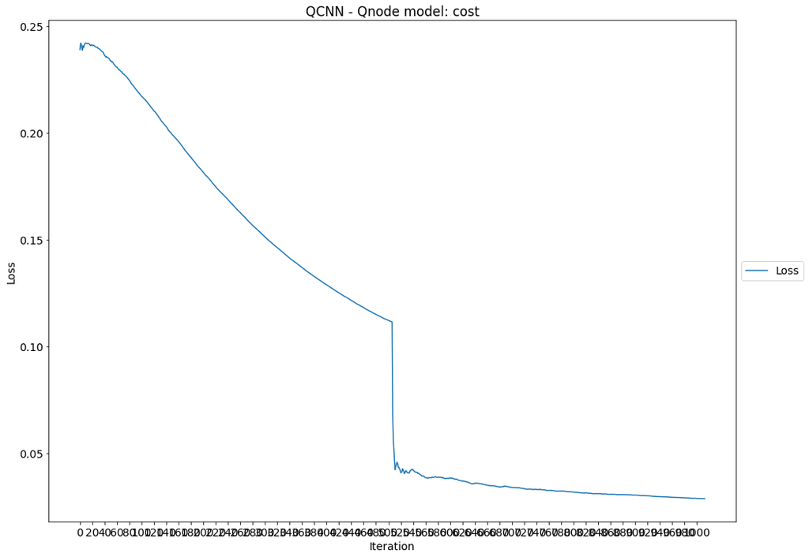

```python
# Plot accuracy, loss of the model
import matplotlib.pyplot as plt

plt.figure(figsize=(16, 12))
plt.rcParams.update({'font.size': 14})
plt.plot(batch_end_loss)
plt.title('QCNN - Qnode model: cost')
#plt.ylim([0, 1])
plt.xticks(ticks=np.arange(0, len(batch_end_loss), 20),
           labels=np.arange(0, len(batch_end_loss), 20))
plt.ylabel('Loss')
plt.xlabel('Iteration')
plt.legend(['Loss'], loc='center left', bbox_to_anchor=(1, 0.5))
plt.show()
```

```python
# Benchmarking with measured train data
score_train = model_QCNN_chosen.evaluate(
    X_train[0:num_train], Y_train_onehot[0:num_train], verbose=2)
print("Train loss:", score_train[0])
print("Train accuracy:", score_train[1])
```

```
396/396 - 6971s - loss: 0.0225 - accuracy: 0.9853 - 6971s/epoch - 18s/step
Train loss: 0.022466817267461445
Train accuracy: 0.9853138570864588
```

```python
# Benchmarking with measured test data
score_test = model_QCNN_chosen.evaluate(
    X_test[0:num_test], Y_test_onehot[0:num_test], verbose=2)
print("Test loss:", score_test[0])
print("Test accuracy:", score_test[1])
```

```
67/67 - 1146s - loss: 0.0184 - accuracy: 0.9915 - 1146s/epoch - 17s/step
Test loss: 0.018410662233720395
Test accuracy: 0.9914893617021276
```